# BIOS15 – Conceptual Worksheet 3

ANOVA: groups, variation, and interactions

Name: Vaiva Slatkeviciute

Date: 2026-11-11

# Goal

Understand ANOVA as a linear model for categorical predictors, reason about among- and within-group variation, interpret contrasts, and recognize interactions.

# 1. From regression to groups

In regression, a simple linear model can be written as:

$$y_i = \beta_0 + \beta_1 x_i + \varepsilon_i$$

In ANOVA, the predictor can identify categories or treatment levels rather than positions on a continuous scale.

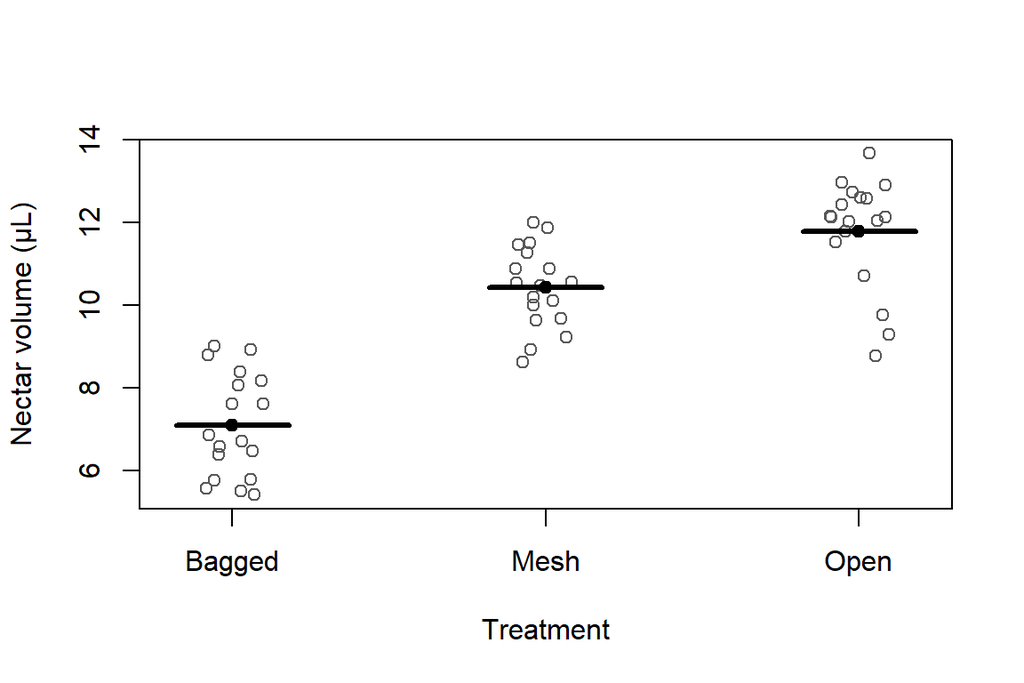

**a.** What is the predictor here, and why is it categorical?

Answer: The predictor is the way flowers have been treated - bagged, meshed or nothing. ______________________________________________________________________________

**b.** Formulate a biological question an ANOVA could address for these data.

Answer: How the pollinators affect the nectar volume? ______________________________________________________________________________

**c.** What information would be lost if we plotted only the three means?

Answer: The variation between individuals. ______________________________________________________________________________

# 2. Where does the variation live?

ANOVA partitions response variation into variation **among groups** and variation **within groups**.

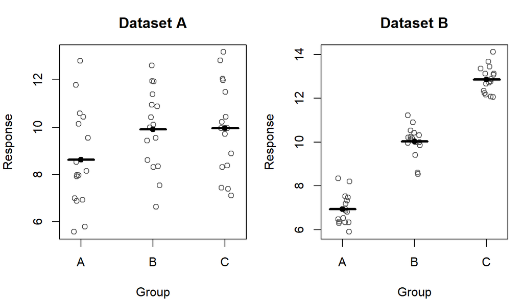

**a.** Which dataset has the larger among-group component?

Answer: dataset B

**b.** Which has more within-group variation relative to separation of its means?

Answer: dataset A

**c.** Predict which should have the larger F-ratio. Explain without using a formula.

Answer: Dataset B should have the larger F-ratio because it has greater among-group variation and smaller within-group variation. ______________________________________________________________________________

The ANOVA F-ratio is:

$$F = \frac{MS_{\text{among}}}{MS_{\text{within}}}$$

**d.** If every observation in Dataset B were multiplied by 10, would that necessarily make evidence for group differences stronger? Explain.

Answer: No, because the ratios between among group and withing group var. would scale 10, so the scale stays the same. ______________________________________________________________________________

# 3. What does a significant ANOVA tell you?

A one-way ANOVA comparing four habitat types gives $P = 0.002$.

Select the **one** statement supported by this result:

- All four habitat means differ.
- At least one habitat mean differs from the others.
- Habitat explains most response variation.
- The habitat effect is biologically large.

What additional information would you want before deciding whether the habitat differences are biologically important?

Answer: Which groups differ from one another, by how much, and with what uncertainty? ______________________________________________________________________________

# 4. Reference levels and contrasts

A model compares mean seed mass among three habitats. **Forest** is the reference level.

$$\hat{\beta}_0 = 18.0\ \text{mg}
\qquad
\hat{\beta}_{\text{meadow}} = +3.0\ \text{mg}
\qquad
\hat{\beta}_{\text{dune}} = -2.0\ \text{mg}$$

**a.** Reconstruct the means:

- Forest: 18 mg
- Meadow: 21 mg
- Dune: 16 mg

**b.** In words, what does $\hat{\beta}_{\text{meadow}} = +3.0$ mg mean?

Answer: Mean seed mass in meadows is 3 mg greater than in the reference habitat, Forest. ______________________________________________________________________________

**c.** If Dune becomes the reference level, which change?

| Quantity | Yes | No |
| --- | --- | --- |
| Group means | [ ] | [X] |
| Reported contrasts | [X] | [ ] |
| Fitted values | [ ] | [X] |

Explain what is fitted values.

**d.** Why is changing the reference level a change in description rather than biology?

Answer: It does not change the data or the habitat means; it only changes the reference point used to describe the contrasts. ______________________________________________________________________________

# 5. Variance explained is not significance

Two experiments both detect treatment differences with $P < 0.001$. Treatment explains **8%** of total variance in Experiment A and **62%** in Experiment B.

**a.** Which shows stronger separation among treatments relative to other variation?

Answer: Experiment B

**b.** Why does the P-value alone not communicate this difference?

Answer: It only indicates if the difference is statistically significant, it could be a very small difference, but with enough samples p-value can be small enough. ______________________________________________________________________________

# 6. When effects depend on context: interactions

A plant-growth experiment manipulates temperature and water supply. Each panel shows a different possible outcome.

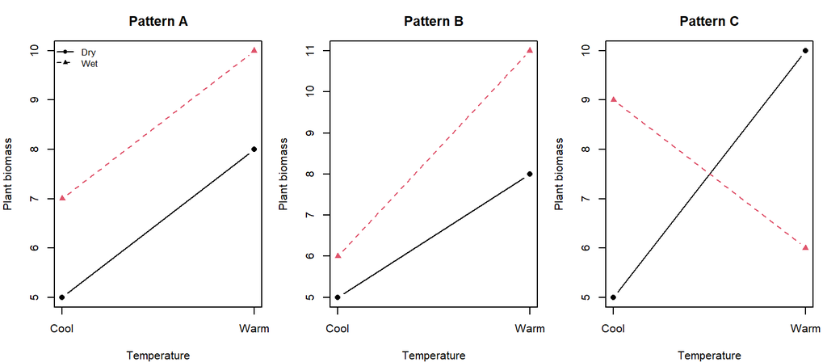

**a.** Which pattern shows essentially no interaction?

Answer: Pattern A - parallel lines.

**b.** Where does warming have effects of different magnitude under Dry and Wet conditions?

Answer: Pattern B - warming has a larger effect under wet conditions.

**c.** Where does the direction of warming’s effect depend on water supply?

Answer: Pattern C - warming has opposite effects under dry and wet conditions.

**d.** Explain an interaction without using the word “significant.”

Answer: If the wettness has effect on growth in context of temperature, the effect increase can differ by a different ratio. ______________________________________________________________________________

**e.** Why are non-parallel lines a useful visual clue?

Answer: Non-parallel lines indicate an interaction between two factors because the effect of one factor changes across levels of the other. ______________________________________________________________________________

# 7. Turn model output into biology

A tadpole experiment compares growth under predator-cue treatments. Control mean = **24.0 mg/day**. Weak cues reduce growth by **1.5 mg/day**; strong cues reduce it by **6.0 mg/day**. Overall ANOVA: $P < 0.001$.

**a.** Write a biologically informative Results sentence without making the P-value the main result.

Answer: Predator-cue treatments reduce the growth of tadpoles, the stronger the cue - the more reduction there is 1.5 and 6.0 mg/day for medium and stron cues respectivelly. The difference is statistically significant. ______________________________________________________________________________

**b.** Strong cues reduce growth by what percentage relative to control?

Calculation:

Answer: 25 % (6.0 / 24.0 × 100)

**c.** What information about variation or uncertainty would help evaluate these estimates?

Answer: The standard error, sd among groups, and p-values between each group.

# Exit ticket

**ANOVA is useful when I want to understand…** Is there a difference between group means.

# 1. What ANOVA is for

When predictor variables are categorical (factors), linear models can be used to perform analyses of variance (ANOVA). Parameter estimation works much like regression, except that the model estimates group effects and contrasts between factor levels rather than regression slopes.

The aim of ANOVA is to partition variation in a response into additive components. In a one-way ANOVA, total variation is divided into variation among groups and variation within groups (the residual variation):

$$SS_T = SS_{among} + SS_{within}$$

The **total sum of squares** uses each observation’s deviation from the grand mean. The **among-groups sum of squares** describes variation associated with group means. The **within-groups or residual sum of squares** uses each observation’s deviation from its own group mean. ANOVA evaluates whether the among-groups variation is large relative to the within-groups variation expected by chance.

A statistically supported omnibus test indicates that **at least one** group mean differs from the others. It does not, by itself, identify which groups differ.

# 2. Assumptions and visualizing groups

For the ANOVA model described in the course, residuals are assumed to be normally distributed within each group and variances are assumed to be equal across groups. Boxplots can help inspect the distributions across factor levels. By default, the box spans the first to third quartiles, the thick line marks the median, whiskers extend to 1.5 times the interquartile range, and individual points beyond the whiskers are shown as outliers.

Boxplots summarize the data; plots that show individual observations can make the pattern more visible. A jittered scatterplot can be combined with a boxplot to reduce overlap and show the observations themselves.

# 3. One-way ANOVA example

The chapter simulates body-size measurements for three groups. The code is reproducible because it sets the random seed.

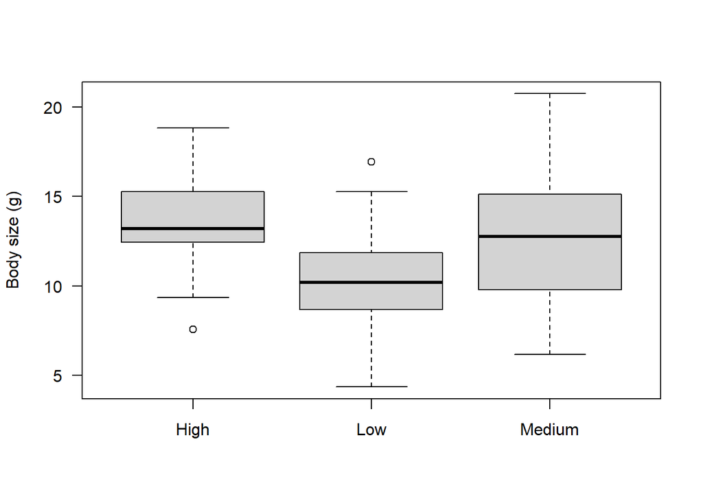

```r
set.seed(100)

groups <- as.factor(rep(c("Low", "Medium", "High"), each = 50))
x <- c(
  rnorm(50, 10, 3),
  rnorm(50, 13, 3),
  rnorm(50, 14, 3)
)

# Inspect the response across factor levels
boxplot(x ~ groups,
        las = 1,
        xlab = "",
        ylab = "Body size (g)")
```

Fit a linear model with `lm()`, then pass the fitted model to `anova()`:

```r
m <- lm(x ~ groups)
anova(m)
```

```
## Analysis of Variance Table
##
## Response: x
##            Df  Sum Sq Mean Sq F value    Pr(>F)
## groups      2  319.97 159.985  19.591 2.866e-08 ***
## Residuals 147 1200.43   8.166
## ---
## Signif. codes:  0 '***' 0.001 '**' 0.01 '*' 0.05 '.' 0.1 ' ' 1
```

## Reading the ANOVA table

- **Degrees of freedom (Df):** for a factor with `k` levels, the factor has `k - 1` degrees of freedom. Residual degrees of freedom are `n - k`, where `n` is the number of observations.
- **Sum Sq:** sums of squares quantify variation. Adding the factor and residual sums of squares gives the total sum of squares.
- **Mean Sq:** each sum of squares divided by its degrees of freedom.
- **F value:** factor mean square divided by residual mean square. This compares among-group variation with within-group variation.
- **Pr(>F):** the p-value for the omnibus test of whether the group means are all equal, under the model assumptions.

For the simulated data there are 3 groups and 150 observations, so factor df is `3 - 1 = 2` and residual df is `150 - 3 = 147`.

The total sum of squares divided by `n - 1` is the sample variance. The following code calculates the total sum of squares from the ANOVA components and compares it with `var(x)`:

```r
a <- anova(m)
SS_T <- sum(a$`Sum Sq`)

SS_T
```

```
## [1] 1520.4
```

```r
SS_T / (length(x) - 1)
```

```
## [1] 10.20403
```

```r
var(x)
```

```
## [1] 10.20403
```

The proportion of total variation explained by the group factor is the model’s R-squared:

```r
SS_among <- a["groups", "Sum Sq"]
R2_from_SS <- SS_among / SS_T
R2_from_SS
```

```
## [1] 0.2104517
```

For this one-factor model, the same quantity can be written as:

$$R^2 = \frac{SS_{among}}{SS_T} = 1 - \frac{SSE}{SST}$$

where `SSE` is the residual (error) sum of squares and `SST` is the total sum of squares.

# 4. Group means and contrasts

The ordinary model summary gives parameter estimates as well as standard errors and tests:

```r
summary(m)
```

```
##
## Call:
## lm(formula = x ~ groups)
##
## Residuals:
##     Min      1Q  Median      3Q     Max
## -6.5887 -1.5596 -0.0987  1.6274  7.9729
##
## Coefficients:
##              Estimate Std. Error t value Pr(>|t|)
## (Intercept)   13.7006     0.4041  33.901  < 2e-16 ***
## groupsLow     -3.4561     0.5715  -6.047 1.16e-08 ***
## groupsMedium  -0.9277     0.5715  -1.623    0.107
## ---
## Signif. codes:  0 '***' 0.001 '**' 0.01 '*' 0.05 '.' 0.1 ' ' 1
##
## Residual standard error: 2.858 on 147 degrees of freedom
## Multiple R-squared:  0.2105, Adjusted R-squared:  0.1997
## F-statistic: 19.59 on 2 and 147 DF,  p-value: 2.866e-08
```

With R’s default treatment contrasts, the intercept is the estimated mean of the reference factor level. The other factor coefficients are contrasts from that reference level. The associated t-tests test whether each group’s mean differs from the reference group’s mean.

In this example, the factor levels are ordered alphabetically, so `High` is the reference level. To choose another reference group, set the factor levels explicitly:

```r
groups <- factor(groups, levels = c("Low", "Medium", "High"))
m_low_reference <- lm(x ~ groups)
summary(m_low_reference)
```

```
##
## Call:
## lm(formula = x ~ groups)
##
## Residuals:
##     Min      1Q  Median      3Q     Max
## -6.5887 -1.5596 -0.0987  1.6274  7.9729
##
## Coefficients:
##              Estimate Std. Error t value Pr(>|t|)
## (Intercept)   10.2445     0.4041  25.349  < 2e-16 ***
## groupsMedium   2.5284     0.5715   4.424 1.88e-05 ***
## groupsHigh     3.4561     0.5715   6.047 1.16e-08 ***
## ---
## Signif. codes:  0 '***' 0.001 '**' 0.01 '*' 0.05 '.' 0.1 ' ' 1
##
## Residual standard error: 2.858 on 147 degrees of freedom
## Multiple R-squared:  0.2105, Adjusted R-squared:  0.1997
## F-statistic: 19.59 on 2 and 147 DF,  p-value: 2.866e-08
```

The parameter estimates describe the magnitude and direction of the group differences. A contrast can also be expressed relative to the reference mean. For example, the chapter’s Low-versus-High contrast is approximately `-3.456 / 13.701 = -0.252`, or 25.2% lower relative to the High-group mean.

> The omnibus ANOVA test and coefficient tests answer related but different questions: the ANOVA test asks whether any group means differ, while each treatment-contrast test compares one level with the reference level.

# 5. Estimating a mean for each group

To estimate a mean for each factor level directly, fit a model without an intercept by adding `-1` to the formula. `confint()` then returns confidence intervals for the estimated means.

```r
m_means <- lm(x ~ groups - 1)
summary(m_means)$coef
```

```
##              Estimate Std. Error  t value     Pr(>|t|)
## groupsLow    10.24453  0.4041333 25.34937 1.586298e-55
## groupsMedium 12.77295  0.4041333 31.60578 1.980446e-67
## groupsHigh   13.70064  0.4041333 33.90129 2.276884e-71
```

```r
confint(m_means)
```

```
##                  2.5 %   97.5 %
## groupsLow     9.445865 11.04319
## groupsMedium 11.974287 13.57161
## groupsHigh   12.901979 14.49930
```

# 6. Key takeaways

1. ANOVA is a linear-model approach for categorical predictors.
2. It partitions total variation into among-groups and within-groups (residual) components.
3. The F statistic compares factor mean square with residual mean square.
4. A supported omnibus test means that at least one group mean differs; it does not name the differing groups.
5. In a model with treatment contrasts, the intercept is the reference-group mean and factor coefficients are contrasts from that level.
6. Choose the reference factor level deliberately and report effect sizes in interpretable units.

*Source: Chapter 3, “The Linear Model II: Analysis of Variance,” Øystein H. Opedal, Department of Biology, Lund University.*

# Exercise

```r
library(tidyverse)
library(ggplot2)
library(car)

df <- read_csv("Supplementary/butterflies.csv")
names(df)
```

```
## [1] "LarvalID"        "LarvalHost"      "Sex"             "MaternalHost"
## [5] "MotherID"        "DevelopmentTime" "AdultWeight"     "GrowthRate"
```

```r
# Research Question: How Maternal and Larval host influence Adult body weight?

# Summary of the data
# Are the observations balanced?
species_pct <- rbind(
  Maternal = prop.table(table(df$MaternalHost)) * 100,
  Larval   = prop.table(table(df$LarvalHost)) * 100)
species_pct
```

```
##          Barbarea Berteroa
## Maternal 54.70383 45.29617
## Larval   62.71777 37.28223
```

```r
# Combination distribution
combination_pct <- prop.table(
  table(Maternal = df$MaternalHost, Larval = df$LarvalHost)) * 100
combination_pct
```

```
##           Larval
## Maternal   Barbarea Berteroa
##   Barbarea 35.54007 19.16376
##   Berteroa 27.17770 18.11847
```

```r
# Means of each group
df$MaternalHost = paste0(df$MaternalHost, "M")
df$LarvalHost = paste0(df$LarvalHost, "L")
means = tapply(df$AdultWeight, list(df$MaternalHost, df$LarvalHost), mean)
means
```

```
##           BarbareaL BerteroaL
## BarbareaM  65.35490  53.50364
## BerteroaM  66.72436  50.37692
```

```r
# Check whether sex is associated with weight
prop.table(table(df$Sex, useNA = "ifany")) * 100
```

```
##
##        F        M
## 51.91638 48.08362
```

```r
tapply(df$AdultWeight, df$Sex, sd, na.rm = TRUE)
```

```
##        F        M
## 11.73748 11.55374
```

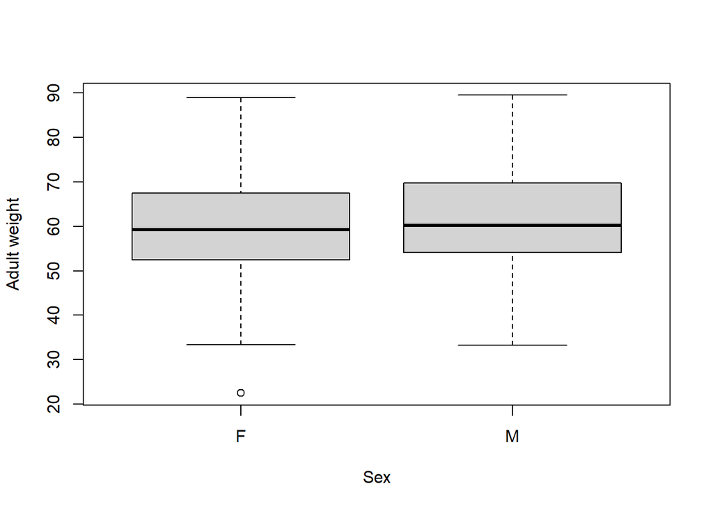

```r
boxplot(AdultWeight ~ Sex, data = df,
        xlab = "Sex", ylab = "Adult weight")
```

```r
aggregate(AdultWeight ~ Sex, data = df, FUN = mean)
```

```
##   Sex AdultWeight
## 1   F    59.97315
## 2   M    61.57246
```

```r
# Independence of observations
length(unique(df$MotherID))
```

```
## [1] 16
```

```r
larvae_per_mother <- table(df$MotherID)
summary(as.numeric(larvae_per_mother))
```

```
##    Min. 1st Qu.  Median    Mean 3rd Qu.    Max.
##    1.00   10.75   15.50   17.94   27.00   38.00
```

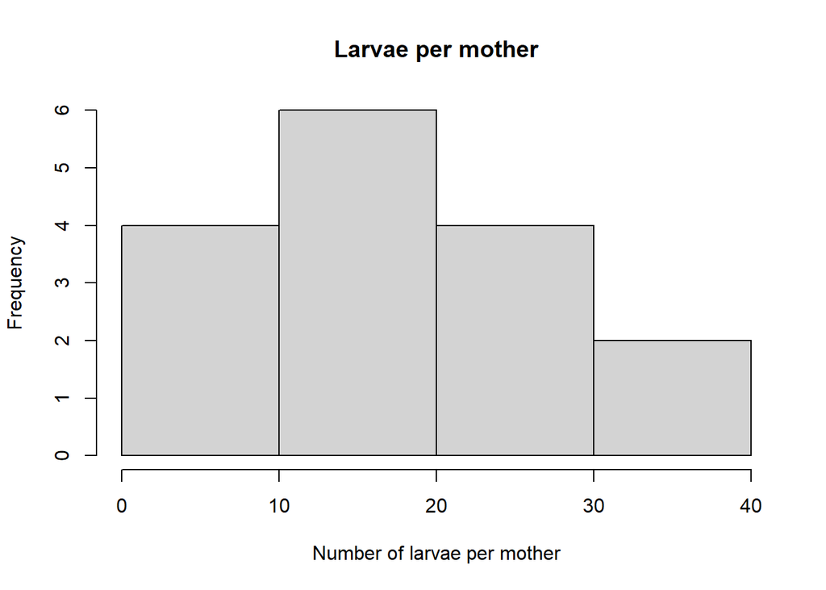

```r
hist(as.numeric(larvae_per_mother),
     xlab = "Number of larvae per mother",
     main = "Larvae per mother")
```

```r
# Create combination variable
df$HostCombination <- paste(df$MaternalHost, df$LarvalHost, sep = "_")

df$HostCombination <- factor(
  df$HostCombination,
  levels = c("BerteroaM_BerteroaL", "BarbareaM_BarbareaL", "BerteroaM_BarbareaL", "BarbareaM_BerteroaL"))

# is variation between groups homogenius
tapply(df$AdultWeight, df$HostCombination, sd, na.rm = TRUE)
```

```
## BerteroaM_BerteroaL BarbareaM_BarbareaL BerteroaM_BarbareaL BarbareaM_BerteroaL
##            8.452349            9.466435           10.401750            9.031938
```

```r
leveneTest(AdultWeight ~ HostCombination, data = df)
```

```
## Levene's Test for Homogeneity of Variance (center = median)
##        Df F value Pr(>F)
## group   3  1.5218  0.209
##       283
```

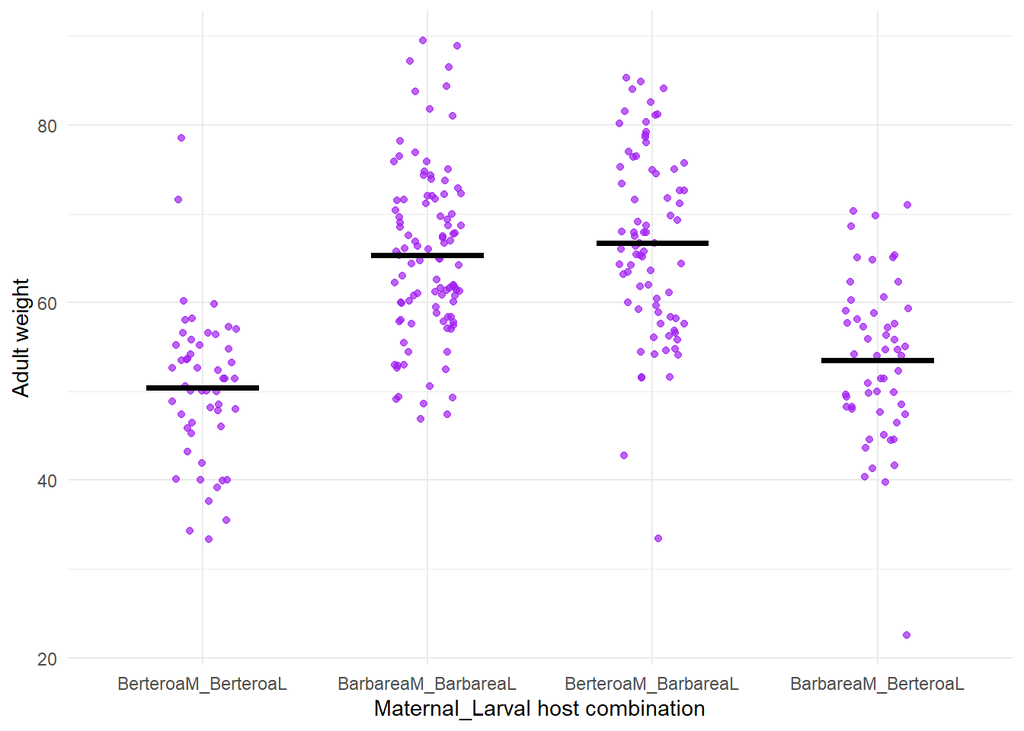

```r
# Plot group means
ggplot(df, aes(x = HostCombination, y = AdultWeight)) +
  geom_jitter(width = 0.15, height = 0, color = "purple", alpha = 0.7) +
  stat_summary(fun = mean, geom = "crossbar", width = 0.5) +
  theme_minimal() +
  labs(x = "Maternal_Larval host combination", y = "Adult weight")
```

```r
# Two-way ANOVA fit the model
m <- lm(AdultWeight ~ MaternalHost * LarvalHost, data = df)
anova(m)
```

```
## Analysis of Variance Table
##
## Response: AdultWeight
##                          Df  Sum Sq Mean Sq  F value Pr(>F)
## MaternalHost              1    73.7    73.7   0.8198 0.3660
## LarvalHost                1 13019.8 13019.8 144.8883 <2e-16 ***
## MaternalHost:LarvalHost   1   336.7   336.7   3.7471 0.0539 .
## Residuals               283 25430.7    89.9
## ---
## Signif. codes:  0 '***' 0.001 '**' 0.01 '*' 0.05 '.' 0.1 ' ' 1
```

```r
summary(m)
```

```
##
## Call:
## lm(formula = AdultWeight ~ MaternalHost * LarvalHost, data = df)
##
## Residuals:
##     Min      1Q  Median      3Q     Max
## -33.324  -6.214  -0.024   6.084  28.123
##
## Coefficients:
##                                           Estimate Std. Error t value Pr(>|t|)
## (Intercept)                                65.3549     0.9386  69.629  < 2e-16
## MaternalHostBerteroaM                       1.3695     1.4259   0.960   0.3377
## LarvalHostBerteroaL                       -11.8513     1.5858  -7.473 9.81e-13
## MaternalHostBerteroaM:LarvalHostBerteroaL  -4.4962     2.3227  -1.936   0.0539
##
## (Intercept)                               ***
## MaternalHostBerteroaM
## LarvalHostBerteroaL                       ***
## MaternalHostBerteroaM:LarvalHostBerteroaL .
## ---
## Signif. codes:  0 '***' 0.001 '**' 0.01 '*' 0.05 '.' 0.1 ' ' 1
##
## Residual standard error: 9.48 on 283 degrees of freedom
## Multiple R-squared:  0.3456, Adjusted R-squared:  0.3387
## F-statistic: 49.82 on 3 and 283 DF,  p-value: < 2.2e-16
```

```r
# Check if residuals are normal distribution
residuals_combo <- split(residuals(m),
  interaction(df$MaternalHost, df$LarvalHost, drop = TRUE)
)

shapiro_results <- data.frame(
  HostCombination = names(residuals_combo),
  Shapiro_p = sapply(residuals_combo, \(x) shapiro.test(x)$p.value)
)
shapiro_results
```

```
##                         HostCombination  Shapiro_p
## BarbareaM.BarbareaL BarbareaM.BarbareaL 0.15447180
## BerteroaM.BarbareaL BerteroaM.BarbareaL 0.14160560
## BarbareaM.BerteroaL BarbareaM.BerteroaL 0.15725364
## BerteroaM.BerteroaL BerteroaM.BerteroaL 0.02425399
```

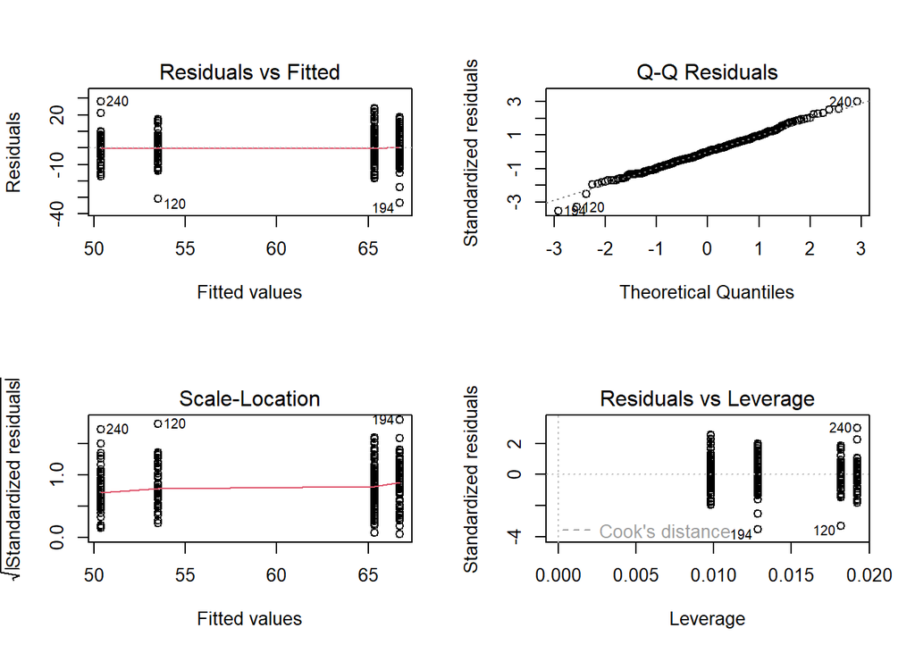

```r
par(mfrow = c(2, 2))
plot(m)
```

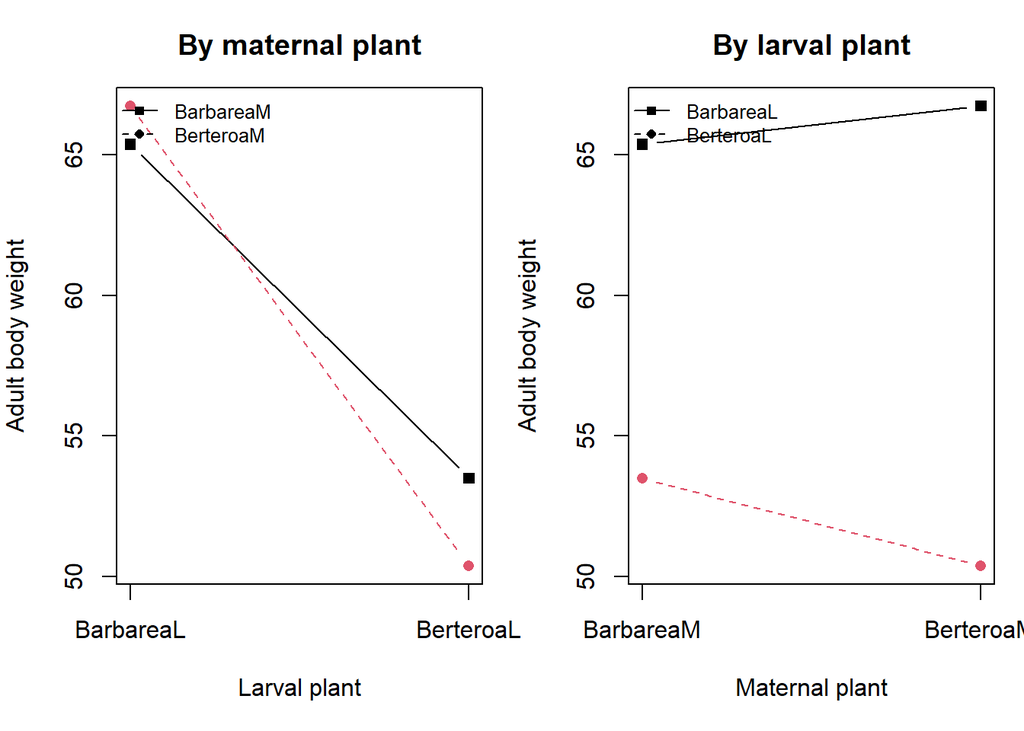

```r
#Plot interaction
maternal_levels <- rownames(means)
larval_levels <- colnames(means)

op <- par(mfrow = c(1, 2), mar = c(5, 4, 3, 1))

# Body weight by larval plant, with separate lines for maternal plant
matplot(seq_along(larval_levels), t(means),
        type = "b", lty = 1:nrow(means), pch = 15:16,
        xaxt = "n", xlab = "Larval plant", ylab = "Adult body weight",
        main = "By maternal plant")
axis(1, at = seq_along(larval_levels), labels = larval_levels)
legend("topleft", legend = maternal_levels,
       lty = 1:nrow(means), pch = 15:16, bty = "n", cex = 0.8)

# Body weight by maternal plant, with separate lines for larval plant
matplot(seq_along(maternal_levels), means,
        type = "b", lty = 1:ncol(means), pch = 15:16,
        xaxt = "n", xlab = "Maternal plant", ylab = "Adult body weight",
        main = "By larval plant")
axis(1, at = seq_along(maternal_levels), labels = maternal_levels)
legend("topleft", legend = larval_levels,
       lty = 1:ncol(means), pch = 15:16, bty = "n", cex = 0.8)
```